# Correlation and linear regression models

Dr Juan H Klopper

## Preamble

In the previous chapter, we compared the same numerical variable between two or more groups, the groups being created from the sample space elements of a categorical variable.

Consider now two different numerical variables, measured for each subject in an experiment. This chapter looks at the *correlation* between these pairs of data point values and also at *linear models* that predict one of the variables given the other (or more variables).

Correlation measures the relationship between the change in the values of one of the variables with respect to the other: “How one *varies* as the other *varies*”. This variation defines the term *covariance*.

Univariable linear regression models take one of the numerical variables as a *dependent variable*. The value of each data point value in this variable is then *predicted* in a model, based on the data point values for another numerical variable, the *independent variable*. Models with only single independent (predictor) variable are termed *univariate models* and models with more than one independent variable are termed *multivariate models*.

## Covariance

Whereas variance looked as the difference between each data point value for a variable and the mean for the variable, covariance considers two numerical variables in correlation. For two variables $x$ and $y$, the covariance can be calculated as shown in equation (1).

$$cov \left(x,y \right) =\frac{\sum_i^n{\left( x_i - \bar{x} \right) \left( y_i - \bar{y} \right)}}{n} \tag{1}$$

This equation simply goes through every pair (meaning that we need data point values for each variable in every pair, i.e. no missing data). It subtracts the mean of the relevant variable from each data point value in turn and multiplies the two differences. It then adds all of these multiplications and divides by the total sample size.

In the code chunk below, we import a spreadsheet file using the built-in `read.csv()` function.

```r
df <- read.csv("ProjectIIData.csv",
               header = TRUE)
```

Now we plot the `CRP` variable against the `Cholesterol` variable. This means that each dot on the plot has as $x$ value, which is the `CRP` value and a $y$ value, which is the `Cholesterol` value.

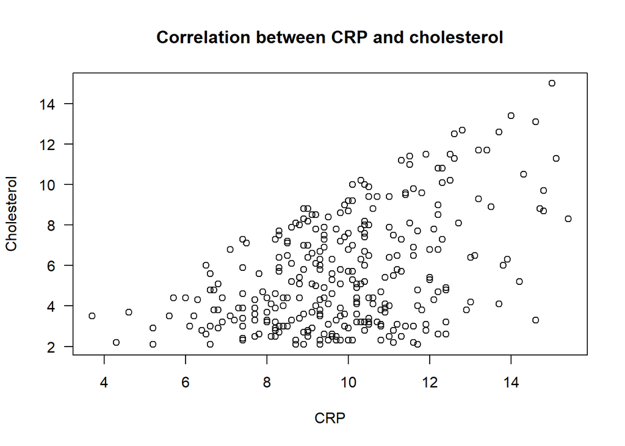

```r
plot(x = df$CRP,
     y = df$Cholesterol,
     main = "Correlation between CRP and cholesterol",
     xlab = "CRP",  # Variable listed first
     ylab = "Cholesterol",  # Variable listed second
     las = 1)
```

The data point values for the two variables were created such that there is some correlation between them. As the values of `CRP` increases, so do the values of `Cholesterol`. Using the equation above, the covariance can be calculated, using the `cov()` command.

```r
cov(df$CRP,
    df$Cholesterol)
```

```
## [1] 2.650898
```

The covariance depends on the units in which the measurements took place, though. It remains for us to standardize the covariance and to express a magnitude of this correlation.

## Correlation coefficient

The task remaining is accomplished by calculating the *correlation coefficient*. It standardizes the covariance by dividing it by the product of the standard deviations of each of the variables and is shown in equation (2). Note that the equation cancels the units involved and the result has a range of -1 to +1.

$$r = \frac{cov \left( x, y \right)}{s_x s_y} \tag{2}$$

This value *r* is also termed the *Pearson product-moment correlation coefficient* and the *Pearson correlation coefficient*. The code snippet below calculates the correlation coefficient.

```r
# Using parenthesis to control the order of arithmetical operations
r = cov(df$CRP, df$Cholesterol) / (sd(df$CRP) * sd(df$Cholesterol))
r
```

```
## [1] 0.4727085
```

A value of $+1$ expresses absolute positive correlation and a value of $-1$ expresses absolute negative correlation. In more human terms, it explains the *effect size*. A value of below and above $-0.1$ and $+0.1$ represents a small effect size. Values over $-0.3$ and $+0.3$ represent a medium effect size, and a values beyond $-0.5$ and $+0.5$ represent a large effect size. This must always be seen in the context of the research question, though.

### Significance tests

While the effect size is arguably of more importance, it remains popular to test for significance. The null hypothesis being that there is no correlation ($r=0$).

The `cor.test()` function calculates the *t* statistic, degrees of freedom, *p* value, 95% confidence intervals around the correlation coefficient and the actual correlation coefficient.

```r
cor.test(df$CRP,
         df$Cholesterol)
```

```
##
##  Pearson's product-moment correlation
##
## data:  df$CRP and df$Cholesterol
## t = 9.2601, df = 298, p-value < 2.2e-16
## alternative hypothesis: true correlation is not equal to 0
## 95 percent confidence interval:
##  0.3797982 0.5561772
## sample estimates:
##       cor
## 0.4727085
```

We note a *t* statistic, the degrees of freedom, and a *p* value. There is also a short summary explaining that we accept the alternative hypothesis, i.e. the correlation is not equal to zero. Then we have the $95$% confidence intervals around the correlation coefficient and the actual correlation coefficient. Everything we need to put in a report or manuscript.

## Univariate linear regression

In univariate linear regression, we aim to build a model that will predict the value of a dependent numerical variable, given a single independent numerical variable. In our contrived example, we might want to predict the `Cholesterol` data point value of a patient, given the `CRP data point value.

Univariate linear models are straight lines. Consider the pairs of values created below. The dependent, `dep` values are simply twice the independent, `indep`, values.

```r
indep <- c(1:10)
dep <- 2 * indep  # Using broadcasting to multiply each value in indep by 2
```

Let’s plot this as a scatter plot.

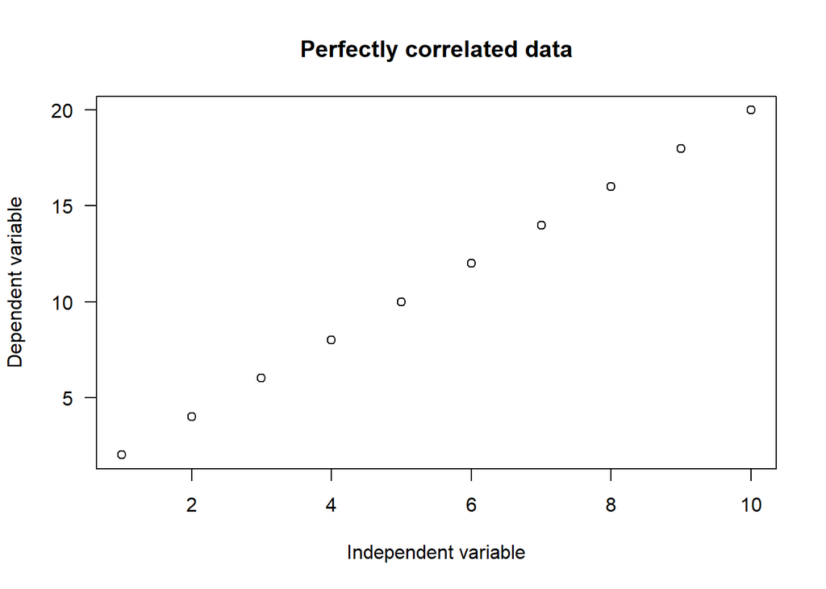

```r
plot(indep,
     dep,
     main = "Perfectly correlated data",
     xlab = "Independent variable",
     ylab = "Dependent variable",
     las = 1)
```

When a patient has an independent variable data point value of $4$, we see that the data point value for their dependent variable is $8$. A straight line can be drawn through all the data point values. You might remember from school that the equation for a straight line is $y = mx + c$, where $y$ is the dependent variable value, $m$ is the slope (rise-over-run), $x$ is the independent variable value, and $b$ is the $y$ intercept (that is where $x-0$.)

The equation for our perfect model would be $y = 2x$. Plugging in any value for $x$, will give us a predicted value for $y$. This is what a linear model does. It allows us to take *unseen* data, i.e. for new patients, plug their (independent) data point value into the model and get a predicted (dependent) variable value. A common reason for building models like this is when the dependent variable is expensive or difficult to measure.

Below, we add the model’s *regression line*, using the `abline()` function. The `lm()` function used as argument here, will be the focus of this section.

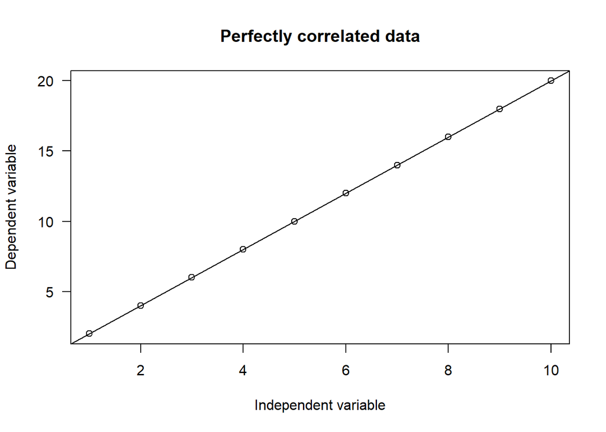

```r
plot(indep,
     dep,
     main = "Perfectly correlated data",
     xlab = "Independent variable",
     ylab = "Dependent variable",
     las = 1)
abline(lm(dep ~ indep))
```

As mentioned, we can now plug in any independent variable value and the model will calculate the value for the dependent variable. For instance, a patient with an independent variable value of $3.5$ will be predicted to have a dependent variable value of $2 \times 3.5 = 7$.

So, let’s look at the `lm()` function. It stands for *linear model*. A linear model is a fantastic beast. It calculates a line that minimizes the error between predicted values and true values. Just to be clear, when given new data such as the $3.5$ above, our model predicts a dependent variable value of $7$. It might be that we have just such a patient in the dataset that we kept a secret and that their dependent variable value was actually $8$. The difference between the predicted and actual values is the *prediction error*, or more commonly, the *residual*.

For fun, we use the `lm()` function on our perfect data. The tilde, `~`, symbol builds the formula for us, such that it reads: *“Predict the dependent variable value given the independent variable.”*.

```r
perfect_model <- lm(dep ~ indep)
summary(perfect_model)  # Printing a summary of the model
```

```
## Warning in summary.lm(perfect_model): essentially perfect fit: summary may
## be unreliable
```

```
##
## Call:
## lm(formula = dep ~ indep)
##
## Residuals:
##        Min         1Q     Median         3Q        Max
## -1.132e-15 -2.314e-16  8.545e-17  4.306e-16  8.334e-16
##
## Coefficients:
##              Estimate Std. Error   t value Pr(>|t|)
## (Intercept) 2.247e-15  4.915e-16 4.571e+00  0.00182 **
## indep       2.000e+00  7.922e-17 2.525e+16  < 2e-16 ***
## ---
## Signif. codes:  0 '***' 0.001 '**' 0.01 '*' 0.05 '.' 0.1 ' ' 1
##
## Residual standard error: 7.195e-16 on 8 degrees of freedom
## Multiple R-squared:      1,  Adjusted R-squared:      1
## F-statistic: 6.374e+32 on 1 and 8 DF,  p-value: < 2.2e-16
```

The `summary()` function of our model shows the residuals. Since there were no differences between the predicted and actual dependent variable values for all $10$ samples, we see the summary statistics of $10$ zero values. Note the rounding constraints of the calculation giving extremely small values, which are in fact equivalent to zero.

Under the `Coefficients` section we see an `Estimate`. The `(Intercept)` value is also zero (bar the rounding) and is the $y$ intercept for the straight line (when $x-0$), i.e. given an independent variable value of $0$, we expect a dependent variable value of $0$. The `Estimate` for the `indep` variable is $2$, the slope of our line. For every single unit rise in the value of our independent variable, the value of the dependent variable will rise by $2$.

In real life, we never see perfect models. We even get a warning at the start of the summary pointing to the fact that our data might be a bit of wishful thinking. Let’s return to our CRP and cholesterol values model. We use the `lm()` function to calculate a model.

```r
uni_lin_model <- lm(Cholesterol ~ CRP,  # Using formula notation
                    data = df)  # Specifying the data fram
summary(uni_lin_model)  # Printing a summary of the model
```

```
##
## Call:
## lm(formula = Cholesterol ~ CRP, data = df)
##
## Residuals:
##     Min      1Q  Median      3Q     Max
## -5.1976 -1.7571 -0.1502  1.7385  6.2556
##
## Coefficients:
##             Estimate Std. Error t value Pr(>|t|)
## (Intercept) -0.51239    0.67136  -0.763    0.446
## CRP          0.61712    0.06664   9.260   <2e-16 ***
## ---
## Signif. codes:  0 '***' 0.001 '**' 0.01 '*' 0.05 '.' 0.1 ' ' 1
##
## Residual standard error: 2.388 on 298 degrees of freedom
## Multiple R-squared:  0.2235, Adjusted R-squared:  0.2208
## F-statistic: 85.75 on 1 and 298 DF,  p-value: < 2.2e-16
```

Above, we did not use `$` notation, but instead specified the data frame object as second argument after the formula.

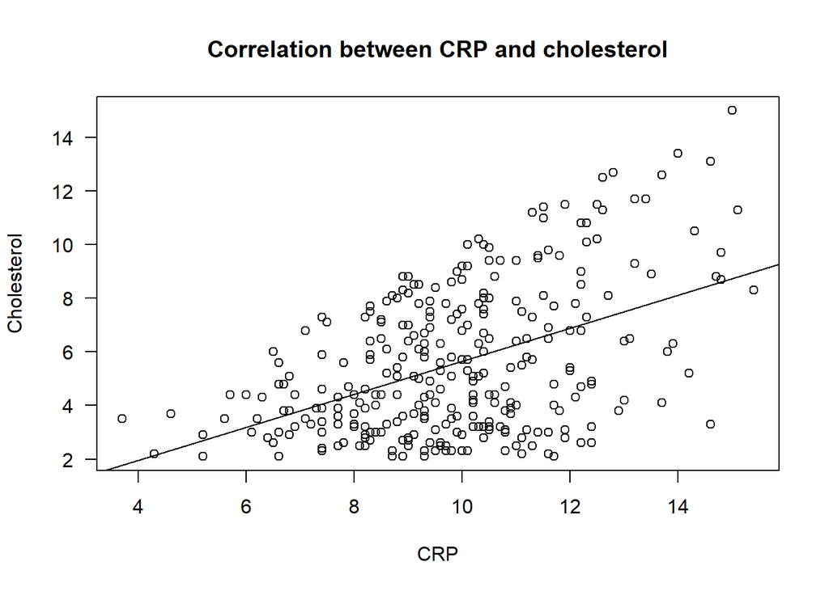

```r
plot(x = df$CRP,
     y = df$Cholesterol,
     main = "Correlation between CRP and cholesterol",
     xlab = "CRP",  # Variable listed first
     ylab = "Cholesterol",  # Variable listed second
     las = 1)
abline(uni_lin_model)
```

For any `CRP` value our model predict a `Cholesterol` value. For most you can see that it is way off the actual value. This error is minimized by this line, though. Any other line would have bigger errors.

We can also see an adjusted $R^2$ value. This is an adjustment to the the square of the correlation coefficient we learned about above and is termed the *coefficient of determination*. In essence, it states that our model explains $22$% of the variance in `Cholesterol`. As an effect size, this is not very good, but we note a *p* value of less than $0.05$, declaring our model statistically significant. These values have to be interpreted in context!

As mentioned, we could have more than one independent variable. For two the results would be a plane rather than a line, and for more than two variable, a hyper-plane. This is unimportant for our discussion. The `lm()` function makes the calculation very easy.

Below, we use both `CRP` and `Triglyceride` to predict `Cholesterol` (again, not very realistic, but it suffices for explanation).

```r
mult_lin_model <- lm(Cholesterol ~ CRP + Triglyceride,
                     data = df)
summary(mult_lin_model)
```

```
##
## Call:
## lm(formula = Cholesterol ~ CRP + Triglyceride, data = df)
##
## Residuals:
##     Min      1Q  Median      3Q     Max
## -5.2929 -1.7988 -0.2887  1.7002  6.0543
##
## Coefficients:
##               Estimate Std. Error t value Pr(>|t|)
## (Intercept)  -2.580794   1.104733  -2.336   0.0201 *
## CRP           0.627690   0.066297   9.468   <2e-16 ***
## Triglyceride  0.006359   0.002709   2.347   0.0196 *
## ---
## Signif. codes:  0 '***' 0.001 '**' 0.01 '*' 0.05 '.' 0.1 ' ' 1
##
## Residual standard error: 2.37 on 297 degrees of freedom
## Multiple R-squared:  0.2376, Adjusted R-squared:  0.2325
## F-statistic: 46.28 on 2 and 297 DF,  p-value: < 2.2e-16
```

We see similar summary results, except that we now have two independent variables, each with their own estimate and *p* value. Overall the adjusted $R^2$ value is slightly higher and this model is better than our original.

## Conclusion

Correlation and linear regression models are fantastic tools for numerical data analysis and very easy to use in R.